```python
import pandas as pd
from os import system
import os
import seaborn as sns
import matplotlib.pyplot as plt
import numpy as np
```

# Web scraping data using pandas

```python
import pandas as pd

url = 'https://www.basketball-reference.com/leagues/NBA_2023_per_game.html'
html = pd.read_html(url, header = 0)
df2023 = html[0]

df2023[60:65]
```

|  | Rk | Player | Pos | Age | Tm | G | GS | MP | FG | FGA | ... | FT% | ORB | DRB | TRB | AST | STL | BLK | TOV | PF | PTS |
| --- | --- | --- | --- | --- | --- | --- | --- | --- | --- | --- | --- | --- | --- | --- | --- | --- | --- | --- | --- | --- | --- |
| 60 | 59 | Dillon Brooks | SG | 27 | MEM | 26 | 26 | 31.0 | 6.8 | 16.6 | ... | .776 | 0.8 | 2.9 | 3.7 | 2.9 | 0.8 | 0.2 | 1.8 | 3.2 | 18.3 |
| 61 | 60 | Bruce Brown | PG | 26 | DEN | 29 | 17 | 30.2 | 4.4 | 9.0 | ... | .800 | 1.0 | 3.4 | 4.3 | 4.3 | 1.0 | 0.6 | 1.7 | 2.5 | 11.2 |
| 62 | Rk | Player | Pos | Age | Tm | G | GS | MP | FG | FGA | ... | FT% | ORB | DRB | TRB | AST | STL | BLK | TOV | PF | PTS |
| 63 | 61 | Greg Brown III | PF | 21 | POR | 9 | 0 | 7.3 | 0.9 | 2.1 | ... | .250 | 0.2 | 1.0 | 1.2 | 0.0 | 0.4 | 0.6 | 0.6 | 0.9 | 2.1 |
| 64 | 62 | Jaylen Brown | SF | 26 | BOS | 29 | 29 | 35.8 | 9.9 | 19.9 | ... | .812 | 1.1 | 6.4 | 7.4 | 3.5 | 1.2 | 0.5 | 3.2 | 2.8 | 26.4 |

5 rows × 30 columns

```python
# df[0] simply refers to the first dataframe: This function searches for <table> elements and only for <tr> and <th> rows
# and <td> elements within each <tr> or <th> element in the table. <td> stands for “table data”.
```

As there're some rows repeating the header, we remvoe it below:

```python
#Data cleaning
raw = df2023.drop(df2023[df2023.Age == 'Age'].index)
raw[58:63]
```

|  | Rk | Player | Pos | Age | Tm | G | GS | MP | FG | FGA | ... | FT% | ORB | DRB | TRB | AST | STL | BLK | TOV | PF | PTS |
| --- | --- | --- | --- | --- | --- | --- | --- | --- | --- | --- | --- | --- | --- | --- | --- | --- | --- | --- | --- | --- | --- |
| 60 | 59 | Dillon Brooks | SG | 27 | MEM | 26 | 26 | 31.0 | 6.8 | 16.6 | ... | .776 | 0.8 | 2.9 | 3.7 | 2.9 | 0.8 | 0.2 | 1.8 | 3.2 | 18.3 |
| 61 | 60 | Bruce Brown | PG | 26 | DEN | 29 | 17 | 30.2 | 4.4 | 9.0 | ... | .800 | 1.0 | 3.4 | 4.3 | 4.3 | 1.0 | 0.6 | 1.7 | 2.5 | 11.2 |
| 63 | 61 | Greg Brown III | PF | 21 | POR | 9 | 0 | 7.3 | 0.9 | 2.1 | ... | .250 | 0.2 | 1.0 | 1.2 | 0.0 | 0.4 | 0.6 | 0.6 | 0.9 | 2.1 |
| 64 | 62 | Jaylen Brown | SF | 26 | BOS | 29 | 29 | 35.8 | 9.9 | 19.9 | ... | .812 | 1.1 | 6.4 | 7.4 | 3.5 | 1.2 | 0.5 | 3.2 | 2.8 | 26.4 |
| 65 | 63 | Kendall Brown | SG | 19 | IND | 6 | 0 | 6.7 | 0.7 | 1.2 | ... | .500 | 0.3 | 0.7 | 1.0 | 0.5 | 0.7 | 0.0 | 0.3 | 1.5 | 1.5 |

5 rows × 30 columns

```python
raw.shape
```

```
(490, 30)
```

```python
raw.info()
```

```
<class 'pandas.core.frame.DataFrame'>
Int64Index: 490 entries, 0 to 513
Data columns (total 30 columns):
 #   Column  Non-Null Count  Dtype
---  ------  --------------  -----
 0   Rk      490 non-null    object
 1   Player  490 non-null    object
 2   Pos     490 non-null    object
 3   Age     490 non-null    object
 4   Tm      490 non-null    object
 5   G       490 non-null    object
 6   GS      490 non-null    object
 7   MP      490 non-null    object
 8   FG      490 non-null    object
 9   FGA     490 non-null    object
```

[output cut: 22 more lines]

```python
# Check for porpotion of missing values
missing_values = raw.isnull().sum()
missing_values_per = (raw.isnull().sum() / raw.isnull().count())
pd.concat([missing_values, missing_values_per],axis=1, keys = ['Count_of_Missing','Percentage'])
r = pd.concat([missing_values, missing_values_per],axis=1, keys = ['Count_of_Missing','Percentage']).reset_index()
r
```

|  | index | Count_of_Missing | Percentage |
| --- | --- | --- | --- |
| 0 | Rk | 0 | 0.000000 |
| 1 | Player | 0 | 0.000000 |
| 2 | Pos | 0 | 0.000000 |
| 3 | Age | 0 | 0.000000 |
| 4 | Tm | 0 | 0.000000 |
| 5 | G | 0 | 0.000000 |
| 6 | GS | 0 | 0.000000 |
| 7 | MP | 0 | 0.000000 |
| 8 | FG | 0 | 0.000000 |
| 9 | FGA | 0 | 0.000000 |
| 10 | FG% | 7 | 0.014286 |
| 11 | 3P | 0 | 0.000000 |
| 12 | 3PA | 0 | 0.000000 |
| 13 | 3P% | 36 | 0.073469 |
| 14 | 2P | 0 | 0.000000 |
| 15 | 2PA | 0 | 0.000000 |
| 16 | 2P% | 14 | 0.028571 |
| 17 | eFG% | 7 | 0.014286 |
| 18 | FT | 0 | 0.000000 |
| 19 | FTA | 0 | 0.000000 |
| 20 | FT% | 43 | 0.087755 |
| 21 | ORB | 0 | 0.000000 |
| 22 | DRB | 0 | 0.000000 |
| 23 | TRB | 0 | 0.000000 |
| 24 | AST | 0 | 0.000000 |
| 25 | STL | 0 | 0.000000 |
| 26 | BLK | 0 | 0.000000 |
| 27 | TOV | 0 | 0.000000 |
| 28 | PF | 0 | 0.000000 |
| 29 | PTS | 0 | 0.000000 |

- FG% Field Goal Percentage
- 3P% FG% on 3-Pt FGAs.
- eFG% Effective Field Goal Percentage (Note: This statistic adjusts for the fact that a 3-point field goal is worth one more point than a 2-point field goal.)
- 2P% FG% on 2-Pt FGAs.
- FT% Free Throw Percentage # Fill missing value with 0

```python
df = raw.fillna(0)
df.isnull().sum()
```

```
Rk        0
Player    0
Pos       0
Age       0
Tm        0
G         0
GS        0
MP        0
FG        0
FGA       0
FG%       0
3P        0
3PA       0
3P%       0
2P        0
2PA       0
2P%       0
eFG%      0
FT        0
FTA       0
FT%       0
ORB       0
DRB       0
TRB       0
AST       0
STL       0
BLK       0
TOV       0
PF        0
PTS       0
dtype: int64
```

```python
#drop ranking
df = df.drop(['Rk'], axis=1) #axis=1 is to drop by column
df.tail()
```

|  | Player | Pos | Age | Tm | G | GS | MP | FG | FGA | FG% | ... | FT% | ORB | DRB | TRB | AST | STL | BLK | TOV | PF | PTS |
| --- | --- | --- | --- | --- | --- | --- | --- | --- | --- | --- | --- | --- | --- | --- | --- | --- | --- | --- | --- | --- | --- |
| 509 | Delon Wright | PG | 30 | WAS | 4 | 0 | 22.8 | 2.5 | 6.0 | .417 | ... | .600 | 1.0 | 1.5 | 2.5 | 3.3 | 2.8 | 1.0 | 1.0 | 1.3 | 6.5 |
| 510 | McKinley Wright IV | PG | 24 | DAL | 2 | 0 | 4.0 | 0.5 | 2.0 | .250 | ... | 0 | 1.0 | 0.5 | 1.5 | 1.5 | 0.5 | 0.0 | 0.0 | 0.0 | 1.0 |
| 511 | Thaddeus Young | PF | 34 | TOR | 27 | 9 | 17.2 | 2.3 | 4.2 | .540 | ... | .813 | 1.7 | 2.0 | 3.7 | 1.8 | 1.1 | 0.1 | 0.8 | 1.7 | 5.1 |
| 512 | Trae Young | PG | 24 | ATL | 27 | 27 | 35.7 | 8.7 | 21.2 | .409 | ... | .895 | 0.7 | 2.0 | 2.7 | 9.9 | 0.7 | 0.1 | 3.8 | 1.5 | 27.0 |
| 513 | Ivica Zubac | C | 25 | LAC | 30 | 30 | 29.5 | 4.0 | 6.4 | .617 | ... | .667 | 3.3 | 7.5 | 10.8 | 1.1 | 0.4 | 1.6 | 2.1 | 3.1 | 10.1 |

5 rows × 29 columns

```python
#write to csv
df.to_csv(r'C:/Users/Python/portfolio/nba2023.csv', index = False)
```

```python
#read data back in
# address = "C:/Users/Python/portfolio/"
df = pd.read_csv('nba2023.csv',header=0)
```

```python
pd.reset_option('display.max_rows')
```

```python
# if we want to examine the whole dataset
pd.set_option('display.max_columns', df.shape[0]+1)#or display.max_rows
df
```

|  | Player | Pos | Age | Tm | G | GS | MP | FG | FGA | FG% | 3P | 3PA | 3P% | 2P | 2PA | 2P% | eFG% | FT | FTA | FT% | ORB | DRB | TRB | AST | STL | BLK | TOV | PF | PTS |
| --- | --- | --- | --- | --- | --- | --- | --- | --- | --- | --- | --- | --- | --- | --- | --- | --- | --- | --- | --- | --- | --- | --- | --- | --- | --- | --- | --- | --- | --- |
| 0 | Precious Achiuwa | C | 23 | TOR | 12 | 0 | 20.4 | 3.0 | 7.7 | 0.391 | 0.4 | 2.3 | 0.179 | 2.6 | 5.3 | 0.484 | 0.418 | 2.3 | 2.8 | 0.848 | 2.0 | 5.0 | 7.0 | 1.3 | 0.2 | 0.6 | 1.3 | 1.6 | 8.8 |
| 1 | Steven Adams | C | 29 | MEM | 26 | 26 | 26.5 | 3.6 | 5.9 | 0.604 | 0.0 | 0.0 | 0.000 | 3.6 | 5.9 | 0.608 | 0.604 | 0.9 | 2.8 | 0.333 | 4.7 | 5.5 | 10.2 | 2.3 | 0.8 | 1.2 | 2.1 | 2.5 | 8.1 |
| 2 | Bam Adebayo | C | 25 | MIA | 28 | 28 | 35.0 | 8.1 | 15.4 | 0.528 | 0.0 | 0.4 | 0.100 | 8.1 | 15.1 | 0.538 | 0.529 | 4.4 | 5.2 | 0.841 | 2.4 | 7.4 | 9.8 | 3.3 | 1.0 | 0.7 | 3.1 | 3.3 | 20.7 |
| 3 | Ochai Agbaji | SG | 22 | UTA | 13 | 0 | 8.8 | 1.2 | 2.8 | 0.432 | 0.3 | 1.3 | 0.235 | 0.9 | 1.5 | 0.600 | 0.486 | 0.3 | 0.7 | 0.444 | 0.5 | 0.8 | 1.2 | 0.2 | 0.1 | 0.0 | 0.0 | 0.9 | 3.1 |
| 4 | Santi Aldama | PF | 22 | MEM | 28 | 16 | 24.5 | 3.5 | 7.5 | 0.469 | 1.3 | 3.7 | 0.359 | 2.2 | 3.9 | 0.574 | 0.557 | 1.7 | 2.2 | 0.770 | 1.4 | 4.3 | 5.6 | 1.4 | 0.8 | 0.9 | 0.6 | 2.5 | 10.1 |
| ... | ... | ... | ... | ... | ... | ... | ... | ... | ... | ... | ... | ... | ... | ... | ... | ... | ... | ... | ... | ... | ... | ... | ... | ... | ... | ... | ... | ... | ... |
| 485 | Delon Wright | PG | 30 | WAS | 4 | 0 | 22.8 | 2.5 | 6.0 | 0.417 | 0.8 | 3.0 | 0.250 | 1.8 | 3.0 | 0.583 | 0.479 | 0.8 | 1.3 | 0.600 | 1.0 | 1.5 | 2.5 | 3.3 | 2.8 | 1.0 | 1.0 | 1.3 | 6.5 |
| 486 | McKinley Wright IV | PG | 24 | DAL | 2 | 0 | 4.0 | 0.5 | 2.0 | 0.250 | 0.0 | 0.5 | 0.000 | 0.5 | 1.5 | 0.333 | 0.250 | 0.0 | 0.0 | 0.000 | 1.0 | 0.5 | 1.5 | 1.5 | 0.5 | 0.0 | 0.0 | 0.0 | 1.0 |
| 487 | Thaddeus Young | PF | 34 | TOR | 27 | 9 | 17.2 | 2.3 | 4.2 | 0.540 | 0.1 | 0.7 | 0.211 | 2.1 | 3.5 | 0.606 | 0.558 | 0.5 | 0.6 | 0.813 | 1.7 | 2.0 | 3.7 | 1.8 | 1.1 | 0.1 | 0.8 | 1.7 | 5.1 |
| 488 | Trae Young | PG | 24 | ATL | 27 | 27 | 35.7 | 8.7 | 21.2 | 0.409 | 2.0 | 7.1 | 0.288 | 6.6 | 14.1 | 0.470 | 0.457 | 7.6 | 8.5 | 0.895 | 0.7 | 2.0 | 2.7 | 9.9 | 0.7 | 0.1 | 3.8 | 1.5 | 27.0 |
| 489 | Ivica Zubac | C | 25 | LAC | 30 | 30 | 29.5 | 4.0 | 6.4 | 0.617 | 0.0 | 0.0 | 0.000 | 4.0 | 6.4 | 0.620 | 0.617 | 2.1 | 3.2 | 0.667 | 3.3 | 7.5 | 10.8 | 1.1 | 0.4 | 1.6 | 2.1 | 3.1 | 10.1 |

490 rows × 29 columns

```python
# pd.set_option('display.max_rows', 10);df
```

```python
df.dtypes
```

```
Player     object
Pos        object
Age         int64
Tm         object
G           int64
GS          int64
MP        float64
FG        float64
FGA       float64
FG%       float64
3P        float64
3PA       float64
3P%       float64
2P        float64
2PA       float64
2P%       float64
eFG%      float64
FT        float64
FTA       float64
FT%       float64
ORB       float64
DRB       float64
TRB       float64
AST       float64
STL       float64
BLK       float64
TOV       float64
PF        float64
PTS       float64
dtype: object
```

# Show specific data types in dataframe

```python
df.select_dtypes(include=['number'])
```

|  | Age | G | GS | MP | FG | FGA | FG% | 3P | 3PA | 3P% | 2P | 2PA | 2P% | eFG% | FT | FTA | FT% | ORB | DRB | TRB | AST | STL | BLK | TOV | PF | PTS |
| --- | --- | --- | --- | --- | --- | --- | --- | --- | --- | --- | --- | --- | --- | --- | --- | --- | --- | --- | --- | --- | --- | --- | --- | --- | --- | --- |
| 0 | 23 | 12 | 0 | 20.4 | 3.0 | 7.7 | 0.391 | 0.4 | 2.3 | 0.179 | 2.6 | 5.3 | 0.484 | 0.418 | 2.3 | 2.8 | 0.848 | 2.0 | 5.0 | 7.0 | 1.3 | 0.2 | 0.6 | 1.3 | 1.6 | 8.8 |
| 1 | 29 | 26 | 26 | 26.5 | 3.6 | 5.9 | 0.604 | 0.0 | 0.0 | 0.000 | 3.6 | 5.9 | 0.608 | 0.604 | 0.9 | 2.8 | 0.333 | 4.7 | 5.5 | 10.2 | 2.3 | 0.8 | 1.2 | 2.1 | 2.5 | 8.1 |
| 2 | 25 | 28 | 28 | 35.0 | 8.1 | 15.4 | 0.528 | 0.0 | 0.4 | 0.100 | 8.1 | 15.1 | 0.538 | 0.529 | 4.4 | 5.2 | 0.841 | 2.4 | 7.4 | 9.8 | 3.3 | 1.0 | 0.7 | 3.1 | 3.3 | 20.7 |
| 3 | 22 | 13 | 0 | 8.8 | 1.2 | 2.8 | 0.432 | 0.3 | 1.3 | 0.235 | 0.9 | 1.5 | 0.600 | 0.486 | 0.3 | 0.7 | 0.444 | 0.5 | 0.8 | 1.2 | 0.2 | 0.1 | 0.0 | 0.0 | 0.9 | 3.1 |
| 4 | 22 | 28 | 16 | 24.5 | 3.5 | 7.5 | 0.469 | 1.3 | 3.7 | 0.359 | 2.2 | 3.9 | 0.574 | 0.557 | 1.7 | 2.2 | 0.770 | 1.4 | 4.3 | 5.6 | 1.4 | 0.8 | 0.9 | 0.6 | 2.5 | 10.1 |
| ... | ... | ... | ... | ... | ... | ... | ... | ... | ... | ... | ... | ... | ... | ... | ... | ... | ... | ... | ... | ... | ... | ... | ... | ... | ... | ... |
| 485 | 30 | 4 | 0 | 22.8 | 2.5 | 6.0 | 0.417 | 0.8 | 3.0 | 0.250 | 1.8 | 3.0 | 0.583 | 0.479 | 0.8 | 1.3 | 0.600 | 1.0 | 1.5 | 2.5 | 3.3 | 2.8 | 1.0 | 1.0 | 1.3 | 6.5 |
| 486 | 24 | 2 | 0 | 4.0 | 0.5 | 2.0 | 0.250 | 0.0 | 0.5 | 0.000 | 0.5 | 1.5 | 0.333 | 0.250 | 0.0 | 0.0 | 0.000 | 1.0 | 0.5 | 1.5 | 1.5 | 0.5 | 0.0 | 0.0 | 0.0 | 1.0 |
| 487 | 34 | 27 | 9 | 17.2 | 2.3 | 4.2 | 0.540 | 0.1 | 0.7 | 0.211 | 2.1 | 3.5 | 0.606 | 0.558 | 0.5 | 0.6 | 0.813 | 1.7 | 2.0 | 3.7 | 1.8 | 1.1 | 0.1 | 0.8 | 1.7 | 5.1 |
| 488 | 24 | 27 | 27 | 35.7 | 8.7 | 21.2 | 0.409 | 2.0 | 7.1 | 0.288 | 6.6 | 14.1 | 0.470 | 0.457 | 7.6 | 8.5 | 0.895 | 0.7 | 2.0 | 2.7 | 9.9 | 0.7 | 0.1 | 3.8 | 1.5 | 27.0 |
| 489 | 25 | 30 | 30 | 29.5 | 4.0 | 6.4 | 0.617 | 0.0 | 0.0 | 0.000 | 4.0 | 6.4 | 0.620 | 0.617 | 2.1 | 3.2 | 0.667 | 3.3 | 7.5 | 10.8 | 1.1 | 0.4 | 1.6 | 2.1 | 3.1 | 10.1 |

490 rows × 26 columns

```python
df.select_dtypes(include=['object'])
```

|  | Player | Pos | Tm |
| --- | --- | --- | --- |
| 0 | Precious Achiuwa | C | TOR |
| 1 | Steven Adams | C | MEM |
| 2 | Bam Adebayo | C | MIA |
| 3 | Ochai Agbaji | SG | UTA |
| 4 | Santi Aldama | PF | MEM |
| ... | ... | ... | ... |
| 485 | Delon Wright | PG | WAS |
| 486 | McKinley Wright IV | PG | DAL |
| 487 | Thaddeus Young | PF | TOR |
| 488 | Trae Young | PG | ATL |
| 489 | Ivica Zubac | C | LAC |

490 rows × 3 columns

## Q1. Which player scored the most Points (PTS) Per Game?

```python
df[df.PTS == df.PTS.max()]
```

|  | Player | Pos | Age | Tm | G | GS | MP | FG | FGA | FG% | 3P | 3PA | 3P% | 2P | 2PA | 2P% | eFG% | FT | FTA | FT% | ORB | DRB | TRB | AST | STL | BLK | TOV | PF | PTS |
| --- | --- | --- | --- | --- | --- | --- | --- | --- | --- | --- | --- | --- | --- | --- | --- | --- | --- | --- | --- | --- | --- | --- | --- | --- | --- | --- | --- | --- | --- |
| 130 | Joel Embiid | C | 28 | PHI | 20 | 20 | 35.6 | 11.1 | 20.7 | 0.535 | 1.1 | 3.3 | 0.338 | 10.0 | 17.4 | 0.572 | 0.562 | 10.1 | 11.9 | 0.849 | 1.8 | 8.1 | 9.9 | 4.7 | 1.2 | 1.6 | 4.2 | 3.1 | 33.3 |

### what team is the player from?

```python
df.Tm[df.PTS == df.PTS.max()]
```

```
130    PHI
Name: Tm, dtype: object
```

```python
#method2
PlayerMaxPoints = df[df.PTS == df.PTS.max()]
PlayerMaxPoints.Tm
```

```
130    PHI
Name: Tm, dtype: object
```

### Which position is the player playing as?

```python
df.Pos[df.PTS == df.PTS.max()]
```

```
130    C
Name: Pos, dtype: object
```

```python
### How many games did the player played in the season?
```

```python
PlayerMaxPoints.G
```

```
130    20
Name: G, dtype: int64
```

## Q2.Which player scored more than 20 Points (PTS) Per Game?

```python
df[df.PTS >20]
```

|  | Player | Pos | Age | Tm | G | GS | MP | FG | FGA | FG% | 3P | 3PA | 3P% | 2P | 2PA | 2P% | eFG% | FT | FTA | FT% | ORB | DRB | TRB | AST | STL | BLK | TOV | PF | PTS |
| --- | --- | --- | --- | --- | --- | --- | --- | --- | --- | --- | --- | --- | --- | --- | --- | --- | --- | --- | --- | --- | --- | --- | --- | --- | --- | --- | --- | --- | --- |
| 2 | Bam Adebayo | C | 25 | MIA | 28 | 28 | 35.0 | 8.1 | 15.4 | 0.528 | 0.0 | 0.4 | 0.100 | 8.1 | 15.1 | 0.538 | 0.529 | 4.4 | 5.2 | 0.841 | 2.4 | 7.4 | 9.8 | 3.3 | 1.0 | 0.7 | 3.1 | 3.3 | 20.7 |
| 10 | Giannis Antetokounmpo | PF | 28 | MIL | 24 | 24 | 32.8 | 11.1 | 21.0 | 0.527 | 0.8 | 3.2 | 0.260 | 10.3 | 17.8 | 0.575 | 0.547 | 7.6 | 12.1 | 0.628 | 2.0 | 9.1 | 11.1 | 5.3 | 0.9 | 1.0 | 3.7 | 3.6 | 30.6 |
| 20 | LaMelo Ball | PG | 21 | CHO | 6 | 6 | 33.5 | 8.3 | 18.3 | 0.455 | 4.3 | 11.2 | 0.388 | 4.0 | 7.2 | 0.558 | 0.573 | 2.2 | 2.5 | 0.867 | 0.2 | 3.0 | 3.2 | 6.7 | 0.8 | 0.3 | 2.7 | 3.0 | 23.2 |
| 22 | Paolo Banchero | PF | 20 | ORL | 24 | 24 | 34.8 | 7.1 | 15.9 | 0.448 | 1.3 | 4.0 | 0.316 | 5.9 | 12.0 | 0.491 | 0.487 | 6.5 | 8.5 | 0.761 | 1.3 | 5.5 | 6.8 | 3.9 | 0.9 | 0.6 | 3.0 | 2.4 | 22.0 |
| 23 | Desmond Bane | SG | 24 | MEM | 12 | 12 | 33.6 | 8.3 | 17.8 | 0.465 | 3.8 | 8.5 | 0.451 | 4.4 | 9.3 | 0.477 | 0.573 | 4.3 | 4.8 | 0.912 | 0.5 | 4.4 | 4.9 | 4.8 | 0.6 | 0.3 | 2.3 | 2.4 | 24.7 |
| 34 | Bradley Beal | SG | 29 | WAS | 19 | 19 | 34.8 | 8.7 | 16.6 | 0.522 | 1.6 | 4.8 | 0.341 | 7.1 | 11.8 | 0.596 | 0.571 | 4.2 | 4.8 | 0.870 | 0.8 | 2.8 | 3.6 | 5.3 | 1.1 | 0.6 | 2.8 | 1.9 | 23.2 |
| 45 | Bojan Bogdanović | PF | 33 | DET | 31 | 31 | 31.1 | 7.0 | 14.1 | 0.497 | 2.6 | 6.1 | 0.423 | 4.4 | 8.0 | 0.552 | 0.588 | 4.7 | 5.2 | 0.901 | 0.5 | 3.0 | 3.5 | 2.5 | 0.5 | 0.0 | 2.3 | 1.7 | 21.3 |
| 48 | Devin Booker | SG | 26 | PHO | 28 | 28 | 35.6 | 10.1 | 21.1 | 0.477 | 2.4 | 6.5 | 0.370 | 7.7 | 14.6 | 0.524 | 0.534 | 5.5 | 6.4 | 0.850 | 0.8 | 4.0 | 4.8 | 5.8 | 0.9 | 0.4 | 2.5 | 2.8 | 28.0 |
| 61 | Jaylen Brown | SF | 26 | BOS | 29 | 29 | 35.8 | 9.9 | 19.9 | 0.496 | 2.4 | 7.1 | 0.338 | 7.4 | 12.8 | 0.584 | 0.556 | 4.3 | 5.3 | 0.812 | 1.1 | 6.4 | 7.4 | 3.5 | 1.2 | 0.5 | 3.2 | 2.8 | 26.4 |
| 65 | Jalen Brunson | PG | 26 | NYK | 30 | 30 | 32.1 | 7.4 | 15.8 | 0.469 | 1.6 | 4.2 | 0.373 | 5.8 | 11.6 | 0.504 | 0.519 | 4.4 | 5.0 | 0.893 | 0.4 | 2.8 | 3.2 | 6.2 | 1.2 | 0.2 | 2.1 | 2.5 | 20.8 |
| 69 | Jimmy Butler | SF | 33 | MIA | 20 | 20 | 35.2 | 7.4 | 14.0 | 0.529 | 0.8 | 2.1 | 0.366 | 6.7 | 12.0 | 0.556 | 0.555 | 6.3 | 7.7 | 0.818 | 2.1 | 4.7 | 6.8 | 5.9 | 1.9 | 0.4 | 1.9 | 1.6 | 21.9 |
| 98 | Stephen Curry | PG | 34 | GSW | 26 | 26 | 34.4 | 10.1 | 20.2 | 0.500 | 5.0 | 11.6 | 0.434 | 5.0 | 8.5 | 0.590 | 0.625 | 4.8 | 5.2 | 0.919 | 0.6 | 6.0 | 6.6 | 6.8 | 1.0 | 0.3 | 3.1 | 2.1 | 30.0 |
| 100 | Anthony Davis | C | 29 | LAL | 25 | 25 | 33.4 | 10.2 | 17.2 | 0.593 | 0.4 | 1.2 | 0.290 | 9.8 | 16.0 | 0.617 | 0.603 | 6.6 | 8.0 | 0.826 | 3.1 | 9.0 | 12.1 | 2.6 | 1.3 | 2.1 | 1.9 | 2.7 | 27.4 |
| 106 | DeMar DeRozan | SF | 33 | CHI | 29 | 29 | 35.3 | 9.0 | 17.9 | 0.504 | 0.4 | 1.4 | 0.310 | 8.6 | 16.5 | 0.521 | 0.516 | 7.3 | 8.2 | 0.891 | 0.4 | 4.5 | 4.9 | 4.7 | 0.8 | 0.4 | 2.1 | 2.7 | 25.9 |
| 114 | Luka Dončić | PG | 23 | DAL | 27 | 27 | 36.6 | 11.3 | 22.6 | 0.499 | 2.9 | 8.3 | 0.347 | 8.4 | 14.3 | 0.588 | 0.563 | 7.5 | 10.3 | 0.729 | 0.8 | 7.5 | 8.3 | 8.7 | 1.6 | 0.6 | 3.6 | 2.9 | 33.0 |
| 124 | Kevin Durant | PF | 34 | BRK | 30 | 30 | 36.7 | 10.9 | 19.2 | 0.565 | 1.7 | 4.7 | 0.362 | 9.2 | 14.5 | 0.631 | 0.609 | 6.9 | 7.5 | 0.924 | 0.3 | 6.3 | 6.6 | 5.3 | 0.7 | 1.6 | 3.6 | 2.4 | 30.4 |
| 127 | Anthony Edwards | SG | 21 | MIN | 30 | 30 | 36.4 | 8.2 | 18.0 | 0.456 | 2.6 | 7.1 | 0.363 | 5.6 | 10.9 | 0.517 | 0.528 | 3.9 | 5.3 | 0.747 | 0.7 | 5.2 | 5.9 | 4.3 | 1.9 | 0.4 | 3.2 | 2.8 | 22.9 |
| 130 | Joel Embiid | C | 28 | PHI | 20 | 20 | 35.6 | 11.1 | 20.7 | 0.535 | 1.1 | 3.3 | 0.338 | 10.0 | 17.4 | 0.572 | 0.562 | 10.1 | 11.9 | 0.849 | 1.8 | 8.1 | 9.9 | 4.7 | 1.2 | 1.6 | 4.2 | 3.1 | 33.3 |
| 140 | De'Aaron Fox | PG | 25 | SAC | 25 | 25 | 32.3 | 8.3 | 16.9 | 0.493 | 1.8 | 5.3 | 0.348 | 6.5 | 11.6 | 0.559 | 0.547 | 4.1 | 5.2 | 0.798 | 0.4 | 4.6 | 5.0 | 5.8 | 1.0 | 0.4 | 2.6 | 2.6 | 22.6 |
| 144 | Darius Garland | PG | 23 | CLE | 25 | 25 | 36.2 | 7.1 | 16.7 | 0.424 | 2.4 | 6.4 | 0.379 | 4.6 | 10.2 | 0.453 | 0.498 | 4.2 | 4.7 | 0.881 | 0.4 | 2.4 | 2.8 | 8.0 | 1.4 | 0.2 | 3.2 | 2.0 | 20.8 |
| 148 | Paul George | SF | 32 | LAC | 22 | 22 | 34.1 | 8.1 | 18.0 | 0.448 | 2.9 | 7.5 | 0.380 | 5.2 | 10.5 | 0.498 | 0.528 | 4.4 | 5.0 | 0.874 | 0.7 | 5.5 | 6.3 | 4.9 | 1.4 | 0.5 | 3.5 | 2.6 | 23.5 |
| 151 | Shai Gilgeous-Alexander | SG | 24 | OKC | 27 | 27 | 35.7 | 10.4 | 20.6 | 0.504 | 1.0 | 3.1 | 0.337 | 9.4 | 17.6 | 0.534 | 0.530 | 9.3 | 10.0 | 0.930 | 0.9 | 3.9 | 4.7 | 5.8 | 1.7 | 1.0 | 3.4 | 2.6 | 31.2 |
| 158 | Jerami Grant | PF | 28 | POR | 28 | 28 | 35.7 | 7.1 | 15.1 | 0.472 | 2.7 | 6.0 | 0.446 | 4.5 | 9.1 | 0.488 | 0.560 | 4.9 | 6.1 | 0.797 | 0.9 | 3.1 | 4.0 | 2.6 | 0.8 | 0.8 | 1.9 | 2.3 | 21.9 |
| 161 | Jalen Green | SG | 20 | HOU | 29 | 29 | 34.4 | 7.3 | 17.8 | 0.413 | 2.2 | 7.1 | 0.309 | 5.1 | 10.7 | 0.482 | 0.475 | 4.7 | 5.9 | 0.794 | 0.6 | 3.6 | 4.2 | 3.8 | 0.8 | 0.3 | 3.1 | 1.6 | 21.6 |
| 174 | James Harden | SG | 33 | PHI | 14 | 14 | 37.6 | 6.9 | 15.8 | 0.439 | 2.7 | 7.3 | 0.373 | 4.2 | 8.5 | 0.496 | 0.525 | 5.9 | 6.7 | 0.872 | 0.6 | 5.9 | 6.6 | 10.6 | 1.4 | 0.6 | 3.7 | 2.2 | 22.4 |
| 191 | Tyler Herro | SG | 23 | MIA | 23 | 23 | 34.9 | 7.5 | 16.3 | 0.457 | 3.3 | 8.1 | 0.412 | 4.1 | 8.2 | 0.503 | 0.560 | 2.9 | 3.2 | 0.904 | 0.6 | 5.7 | 6.3 | 4.2 | 0.9 | 0.5 | 2.7 | 1.7 | 21.2 |
| 209 | Brandon Ingram | SF | 25 | NOP | 15 | 15 | 32.1 | 7.3 | 15.4 | 0.472 | 1.9 | 4.0 | 0.467 | 5.4 | 11.4 | 0.474 | 0.532 | 4.4 | 5.1 | 0.868 | 0.5 | 4.6 | 5.1 | 4.7 | 0.9 | 0.7 | 2.8 | 2.2 | 20.8 |
| 210 | Kyrie Irving | PG | 30 | BRK | 22 | 22 | 36.6 | 9.7 | 19.8 | 0.490 | 2.8 | 8.2 | 0.337 | 6.9 | 11.5 | 0.598 | 0.560 | 4.0 | 4.4 | 0.917 | 0.8 | 4.0 | 4.8 | 4.5 | 0.8 | 1.0 | 2.4 | 2.7 | 26.1 |
| 216 | LeBron James | PF | 38 | LAL | 22 | 22 | 36.3 | 10.6 | 21.9 | 0.485 | 2.2 | 7.1 | 0.312 | 8.4 | 14.8 | 0.569 | 0.536 | 3.5 | 4.9 | 0.710 | 1.4 | 7.1 | 8.5 | 6.5 | 1.2 | 0.6 | 3.1 | 1.9 | 27.0 |
| 223 | Keldon Johnson | SF | 23 | SAS | 27 | 27 | 32.6 | 7.5 | 18.2 | 0.411 | 2.7 | 7.7 | 0.348 | 4.8 | 10.5 | 0.458 | 0.485 | 3.4 | 4.7 | 0.738 | 1.0 | 4.2 | 5.2 | 2.9 | 0.8 | 0.1 | 2.3 | 1.9 | 21.1 |
| 226 | Nikola Jokić | C | 27 | DEN | 26 | 26 | 32.9 | 9.4 | 15.1 | 0.621 | 0.8 | 2.5 | 0.318 | 8.6 | 12.6 | 0.682 | 0.648 | 5.6 | 7.0 | 0.802 | 2.2 | 8.8 | 10.9 | 9.0 | 1.5 | 0.7 | 3.7 | 2.8 | 25.2 |
| 252 | Kyle Kuzma | PF | 27 | WAS | 30 | 30 | 35.3 | 8.2 | 17.7 | 0.462 | 2.5 | 7.5 | 0.338 | 5.6 | 10.2 | 0.554 | 0.534 | 2.4 | 3.5 | 0.689 | 1.0 | 6.7 | 7.7 | 3.5 | 0.5 | 0.5 | 2.8 | 2.7 | 21.3 |
| 257 | Zach LaVine | SG | 27 | CHI | 25 | 25 | 34.2 | 7.9 | 17.8 | 0.443 | 2.8 | 7.7 | 0.365 | 5.1 | 10.1 | 0.502 | 0.521 | 3.2 | 3.9 | 0.825 | 0.6 | 3.8 | 4.4 | 4.1 | 1.2 | 0.0 | 2.6 | 2.4 | 21.8 |
| 265 | Damian Lillard | PG | 32 | POR | 18 | 18 | 34.4 | 8.4 | 18.7 | 0.451 | 4.4 | 11.2 | 0.398 | 4.0 | 7.6 | 0.529 | 0.570 | 7.0 | 7.8 | 0.894 | 0.6 | 3.2 | 3.8 | 7.1 | 0.8 | 0.2 | 3.6 | 1.7 | 28.3 |
| 280 | Lauri Markkanen | SF | 25 | UTA | 29 | 29 | 33.9 | 7.9 | 15.0 | 0.528 | 2.7 | 6.5 | 0.418 | 5.2 | 8.5 | 0.611 | 0.618 | 3.7 | 4.4 | 0.843 | 2.1 | 6.3 | 8.3 | 2.2 | 0.6 | 0.7 | 2.1 | 2.2 | 22.3 |
| 289 | Tyrese Maxey | SG | 22 | PHI | 15 | 15 | 36.4 | 8.4 | 18.2 | 0.462 | 2.9 | 6.8 | 0.422 | 5.5 | 11.4 | 0.485 | 0.540 | 3.2 | 4.3 | 0.738 | 0.4 | 3.1 | 3.5 | 4.4 | 1.0 | 0.3 | 2.0 | 2.3 | 22.9 |
| 307 | Donovan Mitchell | SG | 26 | CLE | 27 | 27 | 36.9 | 10.4 | 20.7 | 0.503 | 3.9 | 9.3 | 0.424 | 6.5 | 11.4 | 0.566 | 0.597 | 4.7 | 5.3 | 0.889 | 0.9 | 2.9 | 3.9 | 4.6 | 1.4 | 0.4 | 3.0 | 2.6 | 29.5 |
| 314 | Ja Morant | PG | 23 | MEM | 24 | 24 | 32.0 | 9.3 | 20.6 | 0.453 | 1.7 | 5.0 | 0.339 | 7.6 | 15.5 | 0.491 | 0.495 | 6.3 | 8.6 | 0.734 | 1.3 | 5.3 | 6.7 | 7.7 | 1.1 | 0.3 | 3.6 | 1.9 | 26.7 |
| 319 | Dejounte Murray | SG | 26 | ATL | 25 | 25 | 35.6 | 8.2 | 18.2 | 0.452 | 2.1 | 5.8 | 0.366 | 6.1 | 12.4 | 0.492 | 0.510 | 2.2 | 2.7 | 0.836 | 0.8 | 4.7 | 5.4 | 6.2 | 1.8 | 0.4 | 2.6 | 1.7 | 20.8 |
| 347 | Kelly Oubre Jr. | SF | 27 | CHO | 30 | 28 | 33.2 | 7.7 | 18.2 | 0.426 | 2.4 | 7.6 | 0.319 | 5.3 | 10.5 | 0.503 | 0.493 | 2.8 | 4.0 | 0.714 | 1.5 | 3.7 | 5.2 | 1.2 | 1.7 | 0.4 | 1.1 | 3.0 | 20.7 |
| 360 | Kristaps Porziņģis | PF | 27 | WAS | 29 | 29 | 32.8 | 7.5 | 15.8 | 0.475 | 1.8 | 5.5 | 0.331 | 5.7 | 10.3 | 0.552 | 0.533 | 5.5 | 6.9 | 0.800 | 2.0 | 6.8 | 8.9 | 2.7 | 1.0 | 1.5 | 2.2 | 3.0 | 22.4 |
| 371 | Julius Randle | PF | 28 | NYK | 30 | 30 | 33.8 | 7.5 | 16.4 | 0.455 | 2.4 | 7.1 | 0.333 | 5.1 | 9.3 | 0.548 | 0.527 | 5.2 | 6.6 | 0.793 | 2.0 | 7.1 | 9.1 | 3.6 | 0.7 | 0.2 | 2.7 | 3.1 | 22.5 |
| 389 | Terry Rozier | PG | 28 | CHO | 22 | 22 | 36.0 | 8.0 | 20.1 | 0.396 | 2.5 | 8.0 | 0.314 | 5.5 | 12.1 | 0.449 | 0.458 | 2.5 | 3.0 | 0.831 | 1.1 | 3.4 | 4.5 | 5.5 | 0.7 | 0.2 | 2.5 | 2.1 | 20.9 |
| 405 | Pascal Siakam | C | 28 | TOR | 20 | 20 | 35.6 | 8.7 | 18.2 | 0.475 | 1.4 | 3.9 | 0.346 | 7.3 | 14.3 | 0.510 | 0.512 | 5.7 | 7.4 | 0.769 | 1.8 | 6.5 | 8.3 | 6.8 | 1.0 | 0.5 | 2.3 | 3.3 | 24.3 |
| 408 | Anfernee Simons | SG | 23 | POR | 28 | 28 | 36.0 | 8.3 | 18.4 | 0.449 | 4.0 | 10.3 | 0.387 | 4.3 | 8.1 | 0.526 | 0.556 | 2.9 | 3.2 | 0.900 | 0.3 | 2.7 | 3.0 | 4.3 | 0.8 | 0.2 | 2.2 | 2.4 | 23.4 |
| 425 | Jayson Tatum | PF | 24 | BOS | 29 | 29 | 37.0 | 9.9 | 21.1 | 0.470 | 3.3 | 9.2 | 0.358 | 6.6 | 11.9 | 0.557 | 0.548 | 7.0 | 8.2 | 0.861 | 1.2 | 7.0 | 8.2 | 4.1 | 1.1 | 0.9 | 2.8 | 2.2 | 30.2 |
| 437 | Karl-Anthony Towns | PF | 27 | MIN | 21 | 21 | 33.8 | 7.3 | 14.4 | 0.505 | 1.8 | 5.6 | 0.325 | 5.5 | 8.9 | 0.618 | 0.568 | 4.4 | 5.0 | 0.885 | 1.7 | 6.5 | 8.2 | 5.3 | 0.8 | 0.7 | 3.1 | 3.9 | 20.8 |
| 481 | Zion Williamson | PF | 22 | NOP | 24 | 24 | 33.1 | 9.8 | 16.0 | 0.610 | 0.3 | 0.8 | 0.333 | 9.5 | 15.3 | 0.624 | 0.618 | 5.6 | 7.8 | 0.722 | 2.1 | 5.1 | 7.2 | 4.6 | 1.2 | 0.6 | 3.0 | 2.3 | 25.5 |
| 488 | Trae Young | PG | 24 | ATL | 27 | 27 | 35.7 | 8.7 | 21.2 | 0.409 | 2.0 | 7.1 | 0.288 | 6.6 | 14.1 | 0.470 | 0.457 | 7.6 | 8.5 | 0.895 | 0.7 | 2.0 | 2.7 | 9.9 | 0.7 | 0.1 | 3.8 | 1.5 | 27.0 |

## Q3.Which player had the highest 3-Point Field Goals Per Game (3P) ?

```python
df[df['3P'] == df['3P'].max()]
```

|  | Player | Pos | Age | Tm | G | GS | MP | FG | FGA | FG% | ... | FT% | ORB | DRB | TRB | AST | STL | BLK | TOV | PF | PTS |
| --- | --- | --- | --- | --- | --- | --- | --- | --- | --- | --- | --- | --- | --- | --- | --- | --- | --- | --- | --- | --- | --- |
| 98 | Stephen Curry | PG | 34 | GSW | 26 | 26 | 34.4 | 10.1 | 20.2 | 0.5 | ... | 0.919 | 0.6 | 6.0 | 6.6 | 6.8 | 1.0 | 0.3 | 3.1 | 2.1 | 30.0 |

1 rows × 29 columns

## Q4.Which player had the highest Assists Per Game (AST) ?

```python
df[df['AST'] == df['AST'].max()]
```

|  | Player | Pos | Age | Tm | G | GS | MP | FG | FGA | FG% | ... | FT% | ORB | DRB | TRB | AST | STL | BLK | TOV | PF | PTS |
| --- | --- | --- | --- | --- | --- | --- | --- | --- | --- | --- | --- | --- | --- | --- | --- | --- | --- | --- | --- | --- | --- |
| 170 | Tyrese Haliburton | PG | 22 | IND | 29 | 29 | 33.4 | 7.0 | 15.0 | 0.47 | ... | 0.876 | 0.7 | 3.3 | 4.0 | 10.7 | 1.7 | 0.4 | 2.7 | 1.2 | 19.5 |

1 rows × 29 columns

## Q5. Which player scored the highest (PTS) in the Los Angeles Lakers?

Use groupby() and get_group()

```python
LAL = df.groupby('Tm').get_group('LAL')
LAL[LAL.PTS == LAL.PTS.max()]
```

|  | Player | Pos | Age | Tm | G | GS | MP | FG | FGA | FG% | ... | FT% | ORB | DRB | TRB | AST | STL | BLK | TOV | PF | PTS |
| --- | --- | --- | --- | --- | --- | --- | --- | --- | --- | --- | --- | --- | --- | --- | --- | --- | --- | --- | --- | --- | --- |
| 100 | Anthony Davis | C | 29 | LAL | 25 | 25 | 33.4 | 10.2 | 17.2 | 0.593 | ... | 0.826 | 3.1 | 9.0 | 12.1 | 2.6 | 1.3 | 2.1 | 1.9 | 2.7 | 27.4 |

1 rows × 29 columns

## Q6.Of the 5 positions, which position scores the most points?

```python
df.groupby('Pos').PTS.describe()
```

| Pos | count | mean | std | min | 25% | 50% | 75% | max |
| --- | --- | --- | --- | --- | --- | --- | --- | --- |
| C | 82.0 | 7.992683 | 6.536144 | 0.0 | 3.60 | 6.25 | 11.225 | 33.3 |
| PF | 103.0 | 9.225243 | 7.064794 | 0.0 | 4.10 | 7.10 | 12.150 | 30.6 |
| PG | 94.0 | 9.758511 | 7.719329 | 0.0 | 3.85 | 7.90 | 13.625 | 33.0 |
| SF | 87.0 | 8.156322 | 6.696141 | 0.0 | 3.10 | 6.30 | 10.700 | 26.4 |
| SG | 124.0 | 9.491935 | 7.218119 | 0.0 | 4.20 | 7.35 | 14.325 | 31.2 |

Most scored is made by position PG (9.7585), but they are roughly similar.

```python
# if there's players double-playing different position, we could specify the postion we want
# positions = ['C','PF','SF','PG','SG']
# POS = df[df['Pos'].isin(positions)]
```

# Data Visualization

## 1. Histogram: pandas.hist()

Built in in pandas package

```python
#method2. showing some histogram plots with subquery
PTS_byPOC = df.loc[:,['Pos', 'PTS']];PTS_byPOC.head(10)
```

|  | Pos | PTS |
| --- | --- | --- |
| 0 | C | 8.8 |
| 1 | C | 8.1 |
| 2 | C | 20.7 |
| 3 | SG | 3.1 |
| 4 | PF | 10.1 |
| 5 | SG | 7.1 |
| 6 | SG | 10.9 |
| 7 | C | 13.7 |
| 8 | PG | 9.5 |
| 9 | PF | 7.3 |

```
array([<AxesSubplot:title={'center':'C'}>,
       <AxesSubplot:title={'center':'PF'}>,
       <AxesSubplot:title={'center':'PG'}>,
       <AxesSubplot:title={'center':'SF'}>,
       <AxesSubplot:title={'center':'SG'}>], dtype=object)
```

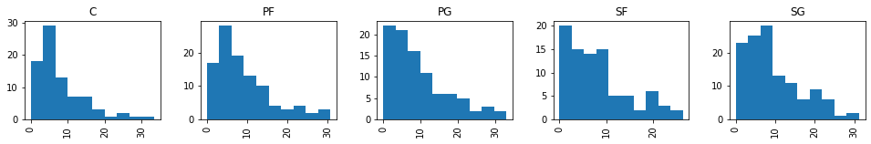

```python
#Pandas's built-in: hist()
PTS_byPOC['PTS'].hist(by=PTS_byPOC['Pos'], layout=(1,5), figsize=(16,2))
#adjust the layout to be 1 row, 5 columns, figure size to be 16 by 2
```

## 2. Seaborn + plt.hist()

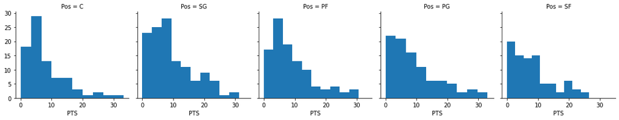

```python
#using seaborn for visualization
import seaborn as sns
import matplotlib.pyplot as plt

g = sns.FacetGrid(PTS_byPOC, col="Pos")#col="Pos" is to separate by position
g.map(plt.hist, "PTS");
```

## 3. pandas.boxplot() + sns.boxplot()

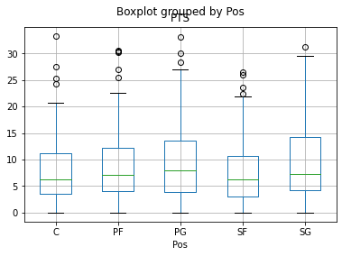

```python
# Boxplot: Pandas built-in function
PTS_byPOC.boxplot(column='PTS', by='Pos')#separated by position
```

We could see that PG has the highest median (the green line), and PG, SG have wide IQR. But with boxplot, we cannot tell if the distribution of the data is centered about two points or pretty much spread even across the data range.

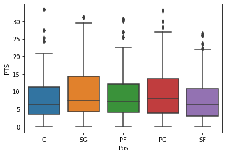

```python
#seaborn
sns.boxplot(x = 'Pos', y = 'PTS', data = PTS_byPOC)
```

### 3.2 Draw a categorical scatterplot using jitter to reduce overplotting.

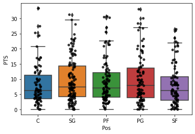

```python
#seaborn with distribution
sns.boxplot(x = 'Pos', y = 'PTS', data = PTS_byPOC)
sns.stripplot(x = 'Pos', y = 'PTS', data = PTS_byPOC,
              jitter=True, #jitter=True so that it would randomize the number wouldn't overlap that much
              marker='o',
              alpha=0.8,
              color="black")
```

## 4. Heatmap: Compute the correlation matrix

```python
corr = df.corr()
corr
```

|  | Age | G | GS | MP | FG | FGA | FG% | 3P | 3PA | 3P% | ... | FT% | ORB | DRB | TRB | AST | STL | BLK | TOV | PF | PTS |
| --- | --- | --- | --- | --- | --- | --- | --- | --- | --- | --- | --- | --- | --- | --- | --- | --- | --- | --- | --- | --- | --- |
| Age | 1.000000 | 0.159212 | 0.132842 | 0.194853 | 0.135578 | 0.135118 | 0.047399 | 0.185041 | 0.169569 | 0.162367 | ... | 0.153684 | 0.018400 | 0.151052 | 0.122201 | 0.201639 | 0.108195 | 0.051617 | 0.123253 | 0.125946 | 0.143828 |
| G | 0.159212 | 1.000000 | 0.570841 | 0.660387 | 0.507420 | 0.496108 | 0.260711 | 0.404251 | 0.400758 | 0.357281 | ... | 0.519808 | 0.365290 | 0.519771 | 0.511673 | 0.351256 | 0.430231 | 0.353793 | 0.444628 | 0.544504 | 0.498598 |
| GS | 0.132842 | 0.570841 | 1.000000 | 0.823201 | 0.750011 | 0.735711 | 0.158568 | 0.522024 | 0.534361 | 0.199406 | ... | 0.299869 | 0.416423 | 0.682113 | 0.653046 | 0.586519 | 0.567224 | 0.407292 | 0.679665 | 0.625034 | 0.739703 |
| MP | 0.194853 | 0.660387 | 0.823201 | 1.000000 | 0.881848 | 0.888401 | 0.198635 | 0.703420 | 0.724868 | 0.374459 | ... | 0.495737 | 0.393880 | 0.762198 | 0.707191 | 0.729320 | 0.724105 | 0.412853 | 0.806826 | 0.750508 | 0.877189 |
| FG | 0.135578 | 0.507420 | 0.750011 | 0.881848 | 1.000000 | 0.976114 | 0.245691 | 0.691450 | 0.708847 | 0.311145 | ... | 0.404055 | 0.354035 | 0.747384 | 0.683531 | 0.729027 | 0.616654 | 0.383947 | 0.862424 | 0.619378 | 0.992162 |
| FGA | 0.135118 | 0.496108 | 0.735711 | 0.888401 | 0.976114 | 1.000000 | 0.116540 | 0.768988 | 0.805842 | 0.333850 | ... | 0.423885 | 0.244066 | 0.678435 | 0.596683 | 0.758266 | 0.634572 | 0.290134 | 0.863502 | 0.584299 | 0.979949 |
| FG% | 0.047399 | 0.260711 | 0.158568 | 0.198635 | 0.245691 | 0.116540 | 1.000000 | -0.022010 | -0.085137 | 0.166674 | ... | 0.224011 | 0.401236 | 0.306384 | 0.359615 | 0.057893 | 0.082793 | 0.333482 | 0.132358 | 0.272159 | 0.207548 |
| 3P | 0.185041 | 0.404251 | 0.522024 | 0.703420 | 0.691450 | 0.768988 | -0.022010 | 1.000000 | 0.976878 | 0.537465 | ... | 0.399525 | -0.102365 | 0.349097 | 0.237383 | 0.551257 | 0.487866 | 0.045615 | 0.569259 | 0.367586 | 0.728648 |
| 3PA | 0.169569 | 0.400758 | 0.534361 | 0.724868 | 0.708847 | 0.805842 | -0.085137 | 0.976878 | 1.000000 | 0.465664 | ... | 0.402237 | -0.104670 | 0.365084 | 0.248687 | 0.586937 | 0.513331 | 0.038251 | 0.607054 | 0.380224 | 0.745555 |
| 3P% | 0.162367 | 0.357281 | 0.199406 | 0.374459 | 0.311145 | 0.333850 | 0.166674 | 0.537465 | 0.465664 | 1.000000 | ... | 0.350987 | -0.126132 | 0.150412 | 0.076443 | 0.255430 | 0.270977 | -0.013835 | 0.241928 | 0.203165 | 0.332980 |
| 2P | 0.086488 | 0.454390 | 0.705365 | 0.788540 | 0.942312 | 0.876371 | 0.320556 | 0.410284 | 0.442561 | 0.144481 | ... | 0.325782 | 0.495928 | 0.782254 | 0.753796 | 0.665678 | 0.553785 | 0.465010 | 0.825029 | 0.612673 | 0.915325 |
| 2PA | 0.084501 | 0.456251 | 0.715922 | 0.812644 | 0.950446 | 0.921114 | 0.225155 | 0.473695 | 0.511868 | 0.179193 | ... | 0.350882 | 0.422466 | 0.744138 | 0.701935 | 0.715077 | 0.583295 | 0.395508 | 0.854209 | 0.598237 | 0.931960 |
| 2P% | 0.016443 | 0.234996 | 0.106733 | 0.179442 | 0.191603 | 0.094287 | 0.779447 | -0.010112 | -0.014082 | -0.005605 | ... | 0.243550 | 0.308206 | 0.245347 | 0.282999 | 0.035400 | 0.079297 | 0.262889 | 0.090982 | 0.235616 | 0.159722 |
| eFG% | 0.092073 | 0.302766 | 0.160649 | 0.243658 | 0.252431 | 0.151065 | 0.941432 | 0.164991 | 0.081243 | 0.409645 | ... | 0.280603 | 0.273493 | 0.263241 | 0.287139 | 0.074387 | 0.116010 | 0.255786 | 0.122583 | 0.255265 | 0.230414 |
| FT | 0.105400 | 0.379465 | 0.617693 | 0.710882 | 0.856493 | 0.832811 | 0.159232 | 0.481143 | 0.514731 | 0.190209 | ... | 0.384281 | 0.291534 | 0.645065 | 0.585328 | 0.658379 | 0.491799 | 0.322495 | 0.792765 | 0.509851 | 0.894742 |
| FTA | 0.097074 | 0.390182 | 0.623342 | 0.710842 | 0.856783 | 0.823312 | 0.190446 | 0.441871 | 0.476559 | 0.163171 | ... | 0.340207 | 0.356829 | 0.683044 | 0.634787 | 0.646852 | 0.492251 | 0.365586 | 0.795450 | 0.536566 | 0.887100 |
| FT% | 0.153684 | 0.519808 | 0.299869 | 0.495737 | 0.404055 | 0.423885 | 0.224011 | 0.399525 | 0.402237 | 0.350987 | ... | 1.000000 | 0.122445 | 0.320337 | 0.283309 | 0.318979 | 0.323849 | 0.123232 | 0.360571 | 0.384503 | 0.423960 |
| ORB | 0.018400 | 0.365290 | 0.416423 | 0.393880 | 0.354035 | 0.244066 | 0.401236 | -0.102365 | -0.104670 | -0.126132 | ... | 0.122445 | 1.000000 | 0.662363 | 0.818288 | 0.105497 | 0.239459 | 0.593019 | 0.300389 | 0.559728 | 0.303925 |
| DRB | 0.151052 | 0.519771 | 0.682113 | 0.762198 | 0.747384 | 0.678435 | 0.306384 | 0.349097 | 0.365084 | 0.150412 | ... | 0.320337 | 0.662363 | 1.000000 | 0.972391 | 0.501924 | 0.470215 | 0.588779 | 0.682977 | 0.696895 | 0.720938 |
| TRB | 0.122201 | 0.511673 | 0.653046 | 0.707191 | 0.683531 | 0.596683 | 0.359615 | 0.237383 | 0.248687 | 0.076443 | ... | 0.283309 | 0.818288 | 0.972391 | 1.000000 | 0.417732 | 0.434041 | 0.635595 | 0.617504 | 0.708653 | 0.647795 |
| AST | 0.201639 | 0.351256 | 0.586519 | 0.729320 | 0.729027 | 0.758266 | 0.057893 | 0.551257 | 0.586937 | 0.255430 | ... | 0.318979 | 0.105497 | 0.501924 | 0.417732 | 1.000000 | 0.653732 | 0.122461 | 0.829124 | 0.480115 | 0.736494 |
| STL | 0.108195 | 0.430231 | 0.567224 | 0.724105 | 0.616654 | 0.634572 | 0.082793 | 0.487866 | 0.513331 | 0.270977 | ... | 0.323849 | 0.239459 | 0.470215 | 0.434041 | 0.653732 | 1.000000 | 0.247064 | 0.614089 | 0.548817 | 0.611637 |
| BLK | 0.051617 | 0.353793 | 0.407292 | 0.412853 | 0.383947 | 0.290134 | 0.333482 | 0.045615 | 0.038251 | -0.013835 | ... | 0.123232 | 0.593019 | 0.588779 | 0.635595 | 0.122461 | 0.247064 | 1.000000 | 0.309305 | 0.505430 | 0.351485 |
| TOV | 0.123253 | 0.444628 | 0.679665 | 0.806826 | 0.862424 | 0.863502 | 0.132358 | 0.569259 | 0.607054 | 0.241928 | ... | 0.360571 | 0.300389 | 0.682977 | 0.617504 | 0.829124 | 0.614089 | 0.309305 | 1.000000 | 0.607959 | 0.863853 |
| PF | 0.125946 | 0.544504 | 0.625034 | 0.750508 | 0.619378 | 0.584299 | 0.272159 | 0.367586 | 0.380224 | 0.203165 | ... | 0.384503 | 0.559728 | 0.696895 | 0.708653 | 0.480115 | 0.548817 | 0.505430 | 0.607959 | 1.000000 | 0.601798 |
| PTS | 0.143828 | 0.498598 | 0.739703 | 0.877189 | 0.992162 | 0.979949 | 0.207548 | 0.728648 | 0.745555 | 0.332980 | ... | 0.423960 | 0.303925 | 0.720938 | 0.647795 | 0.736494 | 0.611637 | 0.351485 | 0.863853 | 0.601798 | 1.000000 |

26 rows × 26 columns

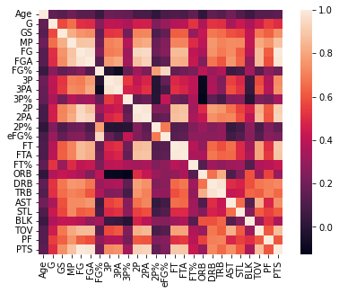

```python
fig, ax = plt.subplots(figsize=(7,5))
sns.heatmap(corr, square=True)
```

The white diagnoial line indicates a correlation, coefficient of 1, and red as 0.5

[output not shown]

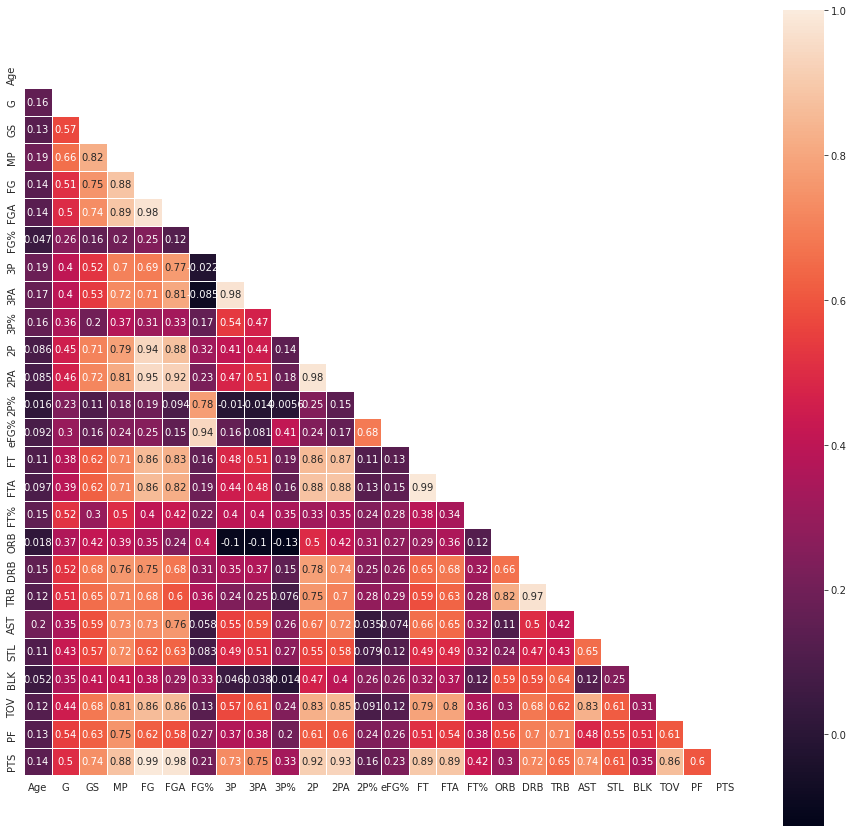

```python
#Mask diagonal half of heat map (Diagonal correlation matrix)
mask = np.zeros_like(corr)
mask[np.triu_indices_from(mask)] = True #Return the indices for the upper-triangle of arr
with sns.axes_style("white"):
    f, ax = plt.subplots(figsize=(16, 15))
    ax = sns.heatmap(corr, mask=mask, vmax=1, square=True, annot=True, linewidth=.5)
```

## 5. Scatter Plot

```python
# subset to numeric only variables
number = df.select_dtypes(include=['number']);
number.iloc[:4,:5]
```

|  | Age | G | GS | MP | FG |
| --- | --- | --- | --- | --- | --- |
| 0 | 23 | 12 | 0 | 20.4 | 3.0 |
| 1 | 29 | 26 | 26 | 26.5 | 3.6 |
| 2 | 25 | 28 | 28 | 35.0 | 8.1 |
| 3 | 22 | 13 | 0 | 8.8 | 1.2 |

```python
#subset to the first 5 and pts columns
selections = ['Age', 'G', 'GS', 'MP', 'FG', 'PTS']
df5 = df[selections]
df5
```

|  | Age | G | GS | MP | FG | PTS |
| --- | --- | --- | --- | --- | --- | --- |
| 0 | 23 | 12 | 0 | 20.4 | 3.0 | 8.8 |
| 1 | 29 | 26 | 26 | 26.5 | 3.6 | 8.1 |
| 2 | 25 | 28 | 28 | 35.0 | 8.1 | 20.7 |
| 3 | 22 | 13 | 0 | 8.8 | 1.2 | 3.1 |
| 4 | 22 | 28 | 16 | 24.5 | 3.5 | 10.1 |
| ... | ... | ... | ... | ... | ... | ... |
| 485 | 30 | 4 | 0 | 22.8 | 2.5 | 6.5 |
| 486 | 24 | 2 | 0 | 4.0 | 0.5 | 1.0 |
| 487 | 34 | 27 | 9 | 17.2 | 2.3 | 5.1 |
| 488 | 24 | 27 | 27 | 35.7 | 8.7 | 27.0 |
| 489 | 25 | 30 | 30 | 29.5 | 4.0 | 10.1 |

490 rows × 6 columns

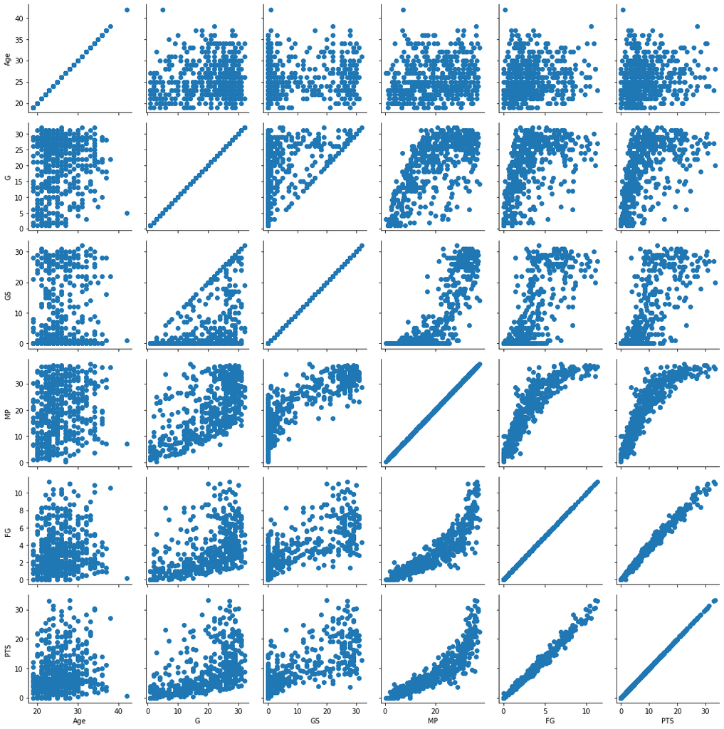

```python
g = sns.PairGrid(df5)
g.map(plt.scatter);
```

```python
# g = sns.PairGrid(number)
# g.map(plt.scatter);
```

Reference:

1. [GeeksforGeeks. Cat command](https://www.geeksforgeeks.org/using-the-cat-command-in-python/)
2. [GeeksforGeeks. Add columns to df](https://www.geeksforgeeks.org/add-column-names-to-dataframe-in-pandas/)
3. [Digitalocean. 3 ways to easily create a subset of Python](https://www.digitalocean.com/community/tutorials/create-subset-of-python-dataframe)
4. [Justinsighting. How to interpret boxplot](https://justinsighting.com/how-to-interpret-box-plots/#:~:text=A%20box%20plot%20gives%20us%20a%20basic%20idea,of%20the%204%20sections%20of%20the%20box%20plot.)
5. [Data Professor. Exploratory Data Analysis in Python using pandas](https://www.youtube.com/watch?v=9m4n2xVzk9o&list=PLtqF5YXg7GLltQSLKSTnwCcHqTZASedbO&index=14)
6. [Seaborn. sns.stripplot documentation](https://seaborn.pydata.org/generated/seaborn.stripplot.html)
7. [Medium. 5min Heatmap](https://medium.com/5-minute-eda/5-minute-eda-correlation-heatmap-b57bbb7bae14)
8. [Seaborn. sns.heatmap documentation](https://seaborn.pydata.org/generated/seaborn.heatmap.html)